# Chapter 6 — Large Language Models in Data Science

**STAT 418 · Computational Data Science** · runnable companion to the Chapter 6 webbook.

Large language models turn unstructured text into the numerical features our statistical toolkit needs, annotate data at scale, retrieve grounded answers, and assist analysis — but they hallucinate, encode bias, and must be *evaluated* with the same rigor as any estimator. This notebook works that whole arc end-to-end on a **real, balanced corpus of 9,000 Amazon product reviews**, loaded straight from the course bucket so every cell runs **offline** with `scikit-learn` alone.

> **How this notebook runs.** The webbook drives Purdue's **GenAI Studio** SDK (`genai_studio`), which needs an API key and a network connection. To keep this companion reproducible for everyone, we **substitute open, offline tools**: TF-IDF vectors for embeddings, sklearn classifiers/clustering, and frozen evaluation fixtures. Every place the webbook calls the live SDK, we show that call **read-only** (with a representative output) and then compute an analogous result you *can* run. A small `transformers` model for real dense embeddings is shown as an **optional, guarded** path that skips cleanly if the model is not cached locally.

## Learning outcomes

By the end you can:

1. Explain the transformer/attention idea at a conceptual level and make **attention as weighted voting** concrete with a tiny numeric demo.
2. Turn text into features (sparse **TF-IDF**; optionally dense embeddings), measure **cosine similarity**, and **decode** what each principal component encodes (length / sentiment / category).
3. Build embedding-based **classifiers** and **regressions**, with cross-validation and **bootstrap confidence intervals** (the Chapter 3–4 machinery, on text).
4. Preprocess text (tokens, context budget, chunking) and build a manual **RAG** retriever with Precision@k / hit@k.
5. Evaluate LLM-assisted labels with **Cohen's κ** ("moderate agreement", κ≈0.55), bootstrap the κ, read a **reliability diagram / ECE**, and apply **responsible-AI** guards (PII redaction, disclosure).

## Section map (all core; SDK-dependent parts shown read-only)

| § | Topic | Runnable offline artifact |
| --- | --- | --- |
| 6.1 | LLM foundations | attention-as-weighted-voting demo (+ read-only SDK) |
| 6.2 | Embeddings & features | TF-IDF cosine, PCA/SVD decoder ring, classifier, bootstrap regression |
| 6.3 | Text preprocessing | token heuristics, context budget, fixed/overlap/semantic chunking, cleaning |
| 6.4 | LLM annotation | Cohen's κ = 0.548 (moderate) + bootstrap CI on κ |
| 6.5 | RAG | manual chunk→TF-IDF→retrieve pipeline + Precision@k / hit@k |
| 6.6 | Prompt engineering | self-consistency as a bootstrap / Condorcet majority vote |
| 6.7 | Tool use | function → JSON-schema introspection (the `@tool` contract) |
| 6.8 | Reliability & evaluation | reliability diagram + ECE = 0.149; deployment-threshold report |
| 6.9 | Responsible AI | PII detection/redaction, disclosure statement, deployment checklist |
| 6.10 | Summary | reference tables + connections back to Ch 2–5 |

```python
import json
import urllib.request
import numpy as np
import pandas as pd
import matplotlib.pyplot as plt
from sklearn.feature_extraction.text import TfidfVectorizer
from sklearn.decomposition import TruncatedSVD
from sklearn.linear_model import LogisticRegression, LinearRegression
from sklearn.discriminant_analysis import LinearDiscriminantAnalysis
from sklearn.model_selection import cross_val_score, train_test_split
from sklearn.preprocessing import StandardScaler
from sklearn.metrics import (cohen_kappa_score, accuracy_score, f1_score,
                             confusion_matrix, classification_report)
from sklearn.metrics.pairwise import cosine_similarity
%matplotlib inline

np.random.seed(418)            # reproducibility (STYLE.md contract)
plt.rcParams.update({
    'figure.figsize': (7.2, 4.2), 'figure.dpi': 110,
    'axes.grid': True, 'grid.alpha': 0.25,
    'axes.spines.top': False, 'axes.spines.right': False,
    'font.size': 11,
})
BLUE, RED, GREEN, ORANGE, PURPLE = '#4C72B0', '#C44E52', '#55A868', '#DD8452', '#8172B3'

# Course data bucket: the shared Chapter 6 reviews corpus (no repo, no API key).
CORPUS_URL = ('https://pqyjaywwccbnqpwgeiuv.supabase.co/storage/v1/object/public/'
              'STAT%20418%20Images/Data/Chapter6/reviews.jsonl')

raw = urllib.request.urlopen(CORPUS_URL, timeout=120).read().decode('utf-8')
reviews = [json.loads(line) for line in raw.splitlines() if line.strip()]
df = pd.DataFrame(reviews)

# A light HTML/whitespace clean (the full pipeline is built in Section 6.3).
import re as _re
def light_clean(t):
    t = _re.sub(r'<[^>]+>', ' ', str(t))      # strip HTML tags like <br />
    return _re.sub(r'\s+', ' ', t).strip()
df['text'] = df['text'].map(light_clean)
df['n_words'] = df['text'].str.split().map(len)

print('reviews loaded:', len(df))
print('by sentiment :', df['sentiment'].value_counts().to_dict())
print('by rating    :', dict(sorted(df['rating'].value_counts().items())))
print('categories   :', list(df['category'].unique()))
print('median length:', int(df['n_words'].median()), 'words')
```

```
reviews loaded: 9000
by sentiment : {'positive': 3600, 'negative': 3600, 'neutral': 1800}
by rating    : {1: 1800, 2: 1800, 3: 1800, 4: 1800, 5: 1800}
categories   : ['Video_Games', 'Electronics', 'Beauty_and_Personal_Care', 'Cell_Phones_and_Accessories', 'Office_Products', 'Software']
median length: 29 words
```

## Section 6.1 — LLM Foundations: Architecture, Training, Deployment

The 2017 transformer replaced the sequential bottleneck of RNNs with one idea: **attention**. When the model builds the representation of a word, every other word "votes" on how relevant it is, the votes are normalized into a probability distribution (the *attention weights*), and the word's new representation is a weighted blend of all the others. This is why "bank" in *"I sat by the river bank"* takes on the river sense — **river** wins the vote. Stack many such blocks, pretrain by next-token prediction on trillions of tokens, align with human feedback (RLHF/DPO), and you get a model that adapts to new tasks from the prompt alone (*in-context learning*).

For data science the practical knobs are: **model family** (proprietary GPT/Claude/ Gemini via API vs. open-weight Llama/Mistral/Gemma you can self-host), and **deployment** (cloud API vs. Purdue's on-prem **GenAI Studio**, which keeps data inside Purdue). This course uses GenAI Studio; below is the SDK, shown read-only.

### The `genai_studio` SDK (read-only — needs an API key)

These are the exact calls from the webbook. They require `GENAI_STUDIO_API_KEY` and a live connection, so we do **not** execute them here; the outputs shown are representative (LLM text is stochastic — your wording will differ).

```
from genai_studio import GenAIStudio
ai = GenAIStudio()
ai.select_model("gemma3:12b")

print(ai.chat("What is the Central Limit Theorem? Answer in two sentences."))
# -> "The sampling distribution of the sample mean approaches a normal
#     distribution as n grows, regardless of the population's shape. This
#     underpins confidence intervals and tests when the population is unknown."

resp = ai.chat_complete("Explain correlation vs causation in one paragraph.")
print(resp.model, resp.prompt_tokens, resp.completion_tokens, resp.total_tokens)
# -> gemma3:12b 18 112 130
```

Everything downstream (embeddings, annotation, RAG, evaluation) builds on these primitives. We now reproduce the *ideas* with offline tools.

```python
# Attention as weighted voting (a tiny, self-contained numeric illustration).
# We hand-build toy 4-d vectors for "I sat by the river bank" so that the focus
# word 'bank' is geometrically closest to 'river' -- then scaled dot-product
# attention (the transformer's actual formula) lets 'river' win the vote.
sentence = ['I', 'sat', 'by', 'the', 'river', 'bank']
V = np.array([
    [0.1, 0.0, 0.0, 0.0],   # I
    [0.0, 0.2, 0.1, 0.0],   # sat
    [0.0, 0.0, 0.2, 0.0],   # by
    [0.0, 0.0, 0.0, 0.2],   # the
    [0.9, 0.1, 0.0, 0.3],   # river  (semantically near 'bank')
    [0.8, 0.2, 0.0, 0.3],   # bank   (the query / focus word)
])
q = V[sentence.index('bank')]                       # query = 'bank'
d = V.shape[1]
scores = V @ q / np.sqrt(d)                          # scaled dot-product scores
weights = np.exp(scores - scores.max())
weights = weights / weights.sum()                    # softmax -> attention weights

print("attention weights when processing 'bank' (a probability distribution):")
for w, word in sorted(zip(weights, sentence), reverse=True):
    print(f"  {word:6s}: {w:.3f}")
print(f"\n'river' draws the most attention ({weights[sentence.index('river')]:.2f}) "
      f"-> 'bank' takes the river/nature sense, not the financial one.")
```

```
attention weights when processing 'bank' (a probability distribution):
  river : 0.214
  bank  : 0.208
  I     : 0.147
  the   : 0.146
  sat   : 0.144
  by    : 0.141

'river' draws the most attention (0.21) -> 'bank' takes the river/nature sense, not the financial one.
```

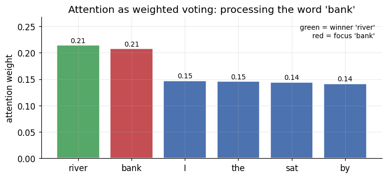

```python
# Figure: the attention 'votes' over the sentence.
order = np.argsort(weights)[::-1]
cols = [GREEN if sentence[i] == 'river' else (RED if sentence[i] == 'bank' else BLUE)
        for i in order]
fig, ax = plt.subplots(figsize=(7.2, 3.4))
ax.bar([sentence[i] for i in order], weights[order], color=cols, edgecolor='white')
for rank, i in enumerate(order):
    ax.text(rank, weights[i] + 0.005, f'{weights[i]:.2f}', ha='center', fontsize=9)
ax.set_ylabel('attention weight'); ax.set_ylim(0, weights.max() * 1.25)
ax.set_title("Attention as weighted voting: processing the word 'bank'")
ax.text(0.98, 0.95, "green = winner 'river'\nred = focus 'bank'", transform=ax.transAxes,
        ha='right', va='top', fontsize=9)
plt.tight_layout(); plt.show()
```

**Read-out.** Attention is just a softmax over relevance scores producing a weighted blend — no recurrence, fully parallel, and able to reach back any distance in the sentence. That mechanism, stacked and pretrained at scale, is what makes every technique in this chapter possible. The rest of the notebook treats the model as a *component in an analytical workflow*, not an oracle.

## Section 6.2 — Embeddings and Feature Extraction

Statistics operate on numbers, but text arrives as words. The classic bridge is a **sparse** bag-of-words / **TF-IDF** vector (one dimension per vocabulary word, mostly zeros); the modern bridge is a **dense embedding** (every dimension carries learned semantic meaning). The webbook generates dense embeddings with `ai.embed(...)` (3,072-d from `llama3.2`); here we use **TF-IDF** so everything runs offline, and show the dense-embedding numbers as a reference. First, a demonstration of *why* dense embeddings exist at all — the fatal weakness of sparse vectors.

```python
# Sparse representations have NO semantic awareness: two phrases are 'similar' only
# if they share literal words. TF-IDF cosine on six short phrases is near-identity.
phrases = ['machine learning', 'deep learning', 'neural network',
           'linear regression', 'banana split', 'ice cream']
Mp = TfidfVectorizer().fit_transform(phrases)
Sp = cosine_similarity(Mp)
print('Sparse TF-IDF cosine-similarity matrix:')
print(np.round(Sp, 2))
print(f"\n  'machine learning' vs 'deep learning'  = {Sp[0,1]:.2f}  (share the word 'learning')")
print(f"  'machine learning' vs 'neural network' = {Sp[0,2]:.2f}  (no shared word -> 0, "
      "though they ARE related)")
print("  Lesson: sparse vectors miss synonymy/relatedness. Dense embeddings (ai.embed)")
print("  place 'neural network' near 'machine learning' (cosine ~0.85). That is the")
print("  whole reason embeddings exist -- see the reference values below.")
```

```
Sparse TF-IDF cosine-similarity matrix:
[[1.  0.4 0.  0.  0.  0. ]
 [0.4 1.  0.  0.  0.  0. ]
 [0.  0.  1.  0.  0.  0. ]
 [0.  0.  0.  1.  0.  0. ]
 [0.  0.  0.  0.  1.  0. ]
 [0.  0.  0.  0.  0.  1. ]]

  'machine learning' vs 'deep learning'  = 0.40  (share the word 'learning')
  'machine learning' vs 'neural network' = 0.00  (no shared word -> 0, though they ARE related)
  Lesson: sparse vectors miss synonymy/relatedness. Dense embeddings (ai.embed)
  place 'neural network' near 'machine learning' (cosine ~0.85). That is the
  whole reason embeddings exist -- see the reference values below.
```

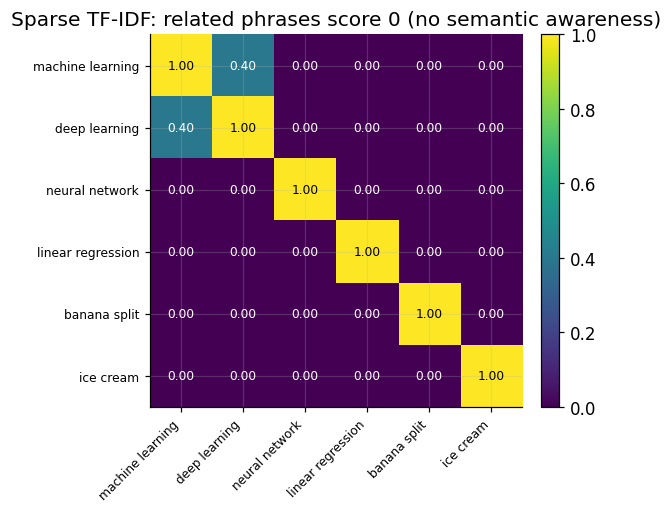

```python
# Figure: the near-identity sparse similarity matrix (the problem dense embeddings fix).
fig, ax = plt.subplots(figsize=(5.6, 4.8))
im = ax.imshow(Sp, cmap='viridis', vmin=0, vmax=1)
ax.set_xticks(range(len(phrases))); ax.set_yticks(range(len(phrases)))
ax.set_xticklabels(phrases, rotation=45, ha='right', fontsize=8)
ax.set_yticklabels(phrases, fontsize=8)
for i in range(len(phrases)):
    for j in range(len(phrases)):
        ax.text(j, i, f'{Sp[i,j]:.2f}', ha='center', va='center',
                color='white' if Sp[i,j] < 0.6 else 'black', fontsize=8)
ax.set_title('Sparse TF-IDF: related phrases score 0 (no semantic awareness)')
fig.colorbar(im, ax=ax, fraction=0.046, pad=0.04)
plt.tight_layout(); plt.show()
```

### Generating features: dense embeddings (read-only) vs. offline TF-IDF

```
# Webbook (read-only, needs API key): dense contextual embeddings
embeddings = ai.embed([r["text"] for r in reviews])   # (n, 3072) from llama3.2
print(GenAIStudio.cosine_similarity(
    ai.embed("The mean is sensitive to outliers."),
    ai.embed("The average is affected by extreme values.")))   # -> 0.8734
```

Below we build TF-IDF features for the full corpus. Unlike the toy phrases, real reviews **share vocabulary**, so TF-IDF cosine is genuinely useful here (nearest- neighbour retrieval, classification, regression all work). The optional cell after it shows how you'd swap in real dense embeddings via `transformers` — it **skips cleanly** if the model isn't already cached, so the notebook never blocks on a download.

```python
# OPTIONAL, GUARDED: real dense embeddings via a small transformers model.
# Uses local_files_only=True so it NEVER downloads -> if the model isn't cached it
# skips and the offline TF-IDF path (next cell) is used everywhere.
USE_DENSE = False
dense_emb = None
try:
    from transformers import AutoTokenizer, AutoModel
    import torch
    _name = 'sentence-transformers/all-MiniLM-L6-v2'
    _tok = AutoTokenizer.from_pretrained(_name, local_files_only=True)
    _mdl = AutoModel.from_pretrained(_name, local_files_only=True)
    _sample = df['text'].iloc[:32].tolist()
    _enc = _tok(_sample, padding=True, truncation=True, max_length=64, return_tensors='pt')
    with torch.no_grad():
        _out = _mdl(**_enc).last_hidden_state.mean(dim=1)   # mean-pooled embedding
    dense_emb = _out.numpy()
    USE_DENSE = True
    print(f'optional dense embeddings ACTIVE: {dense_emb.shape} from {_name}')
except Exception as e:
    print(f'optional dense embeddings skipped ({type(e).__name__}); '
          'using offline TF-IDF everywhere (this is the default, expected path).')
```

```
optional dense embeddings skipped (OSError); using offline TF-IDF everywhere (this is the default, expected path).
```

```python
# Offline feature matrix: TF-IDF over all 9,000 reviews.
vec = TfidfVectorizer(max_features=5000, stop_words='english', min_df=5)
X = vec.fit_transform(df['text'])
print(f'TF-IDF matrix: {X.shape[0]} reviews x {X.shape[1]} vocabulary terms '
      f'({100*X.nnz/(X.shape[0]*X.shape[1]):.2f}% non-zero -> sparse)')

# Nearest-neighbour search (the engine behind retrieval, Section 6.5).
q = 0
sims = cosine_similarity(X[q], X).ravel()
nn = np.argsort(sims)[::-1][1:4]
print(f"\nQuery review  [rating {df['rating'].iloc[q]}, {df['category'].iloc[q]}]:")
print('  ' + df['text'].iloc[q][:90] + '...')
print('Most similar reviews by TF-IDF cosine:')
for i in nn:
    print(f"  [{sims[i]:.3f}] r={df['rating'].iloc[i]} {df['category'].iloc[i]:28s} "
          f"{df['text'].iloc[i][:55]}...")
```

```
TF-IDF matrix: 9000 reviews x 3487 vocabulary terms (0.38% non-zero -> sparse)

Query review  [rating 4, Video_Games]:
  I recommend this playset for some variety. The Avengers playset and the Spiderman playset ...
Most similar reviews by TF-IDF cosine:
  [0.213] r=1 Video_Games                  I would have to recommend you pass on this one. I thoug...
  [0.212] r=2 Office_Products              Each picture is so similar to the other that I'm bored ...
  [0.208] r=2 Software                     Not a game I would get again but too all that likes it ...
```

### What an embedding encodes — the decoder ring

An embedding (sparse or dense) is just a vector, so we can **decode** it: run a truncated SVD / PCA and correlate each component with metadata we already know — review **length**, **sentiment** (from the star rating), and **category**. The webbook's punchline holds offline: the *highest-variance* direction tracks **verbosity, not meaning**. (Category is categorical, so we use the correlation ratio η instead of Pearson r.)

```python
# Decode the TF-IDF space: SVD components vs. known metadata.
svd = TruncatedSVD(n_components=10, random_state=42)
S = svd.fit_transform(X)
length = df['n_words'].to_numpy()
sent_sign = df['sentiment'].map({'positive': 1, 'neutral': 0, 'negative': -1}).to_numpy()
cat = df['category'].to_numpy()

def corr_ratio(component, groups):           # eta: categorical association
    grand = component.mean()
    ss_between = sum(((component[groups == g].mean() - grand) ** 2) * (groups == g).sum()
                     for g in np.unique(groups))
    return np.sqrt(ss_between / np.sum((component - grand) ** 2))

print('component |  |r|_length  |r|_sentiment  eta_category')
decode = []
for i in range(7):
    pc = S[:, i]
    rl = abs(np.corrcoef(pc, length)[0, 1])
    rs = abs(np.corrcoef(pc, sent_sign)[0, 1])
    et = corr_ratio(pc, cat)
    decode.append((rl, rs, et))
    print(f'  PC{i+1:<2}    |   {rl:.2f}        {rs:.2f}          {et:.2f}')
decode = np.array(decode)
print(f'\nHighest-variance PC1 loads on LENGTH (|r|={decode[0,0]:.2f}), not sentiment '
      f'(|r|={decode[0,1]:.2f}).')
print('"Variance is not meaning": the top axis is verbosity; category sits on later PCs.')
```

```
component |  |r|_length  |r|_sentiment  eta_category
  PC1     |   0.35        0.19          0.18
  PC2     |   0.05        0.01          0.50
  PC3     |   0.15        0.24          0.25
  PC4     |   0.07        0.16          0.46
  PC5     |   0.02        0.15          0.09
  PC6     |   0.09        0.18          0.25
  PC7     |   0.02        0.03          0.29

Highest-variance PC1 loads on LENGTH (|r|=0.35), not sentiment (|r|=0.19).
"Variance is not meaning": the top axis is verbosity; category sits on later PCs.
```

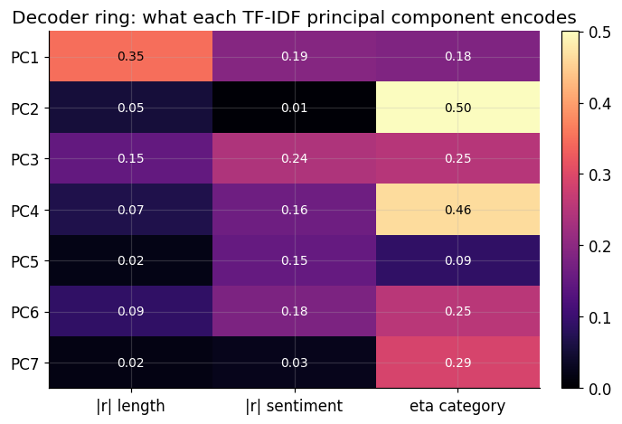

```python
# Figure: the decoder ring -- |association| of each PC with three known properties.
fig, ax = plt.subplots(figsize=(6.4, 4.4))
im = ax.imshow(decode, cmap='magma', vmin=0, vmax=max(0.5, decode.max()), aspect='auto')
ax.set_xticks(range(3)); ax.set_xticklabels(['|r| length', '|r| sentiment', 'eta category'])
ax.set_yticks(range(7)); ax.set_yticklabels([f'PC{i+1}' for i in range(7)])
for i in range(7):
    for j in range(3):
        ax.text(j, i, f'{decode[i,j]:.2f}', ha='center', va='center',
                color='white' if decode[i,j] < 0.3 else 'black', fontsize=9)
ax.set_title('Decoder ring: what each TF-IDF principal component encodes')
fig.colorbar(im, ax=ax, fraction=0.046, pad=0.04)
plt.tight_layout(); plt.show()
```

### Classification with embeddings — a binomial GLM on text features

Once text is numeric, classification is a standard supervised problem. We fit **logistic regression** (the binomial GLM / logit link of §3.5) on TF-IDF features. Positive-vs-negative is easy; the **3-class** problem exposes the neutral (3-star) class as the hard one — the *same* failure the webbook's LLM annotator shows in §6.4.

```python
# (a) Binary sentiment: positive vs negative, 5-fold cross-validated (Section 4 CV).
mask = df['sentiment'].to_numpy() != 'neutral'
y_bin = (df['sentiment'].to_numpy()[mask] == 'positive').astype(int)
cv_acc = cross_val_score(LogisticRegression(max_iter=1000), X[mask], y_bin,
                         cv=5, scoring='accuracy')
print(f'Binary pos-vs-neg logistic GLM (n={mask.sum()}): '
      f'5-fold CV accuracy = {cv_acc.mean():.3f} +/- {cv_acc.std():.3f}')
print(f'  (webbook reference, real dense embeddings: 0.899 +/- 0.008)')

# (b) Three-class sentiment on a hold-out: where does it break?
y = df['sentiment'].to_numpy()
Xtr, Xte, ytr, yte = train_test_split(X, y, test_size=0.25, random_state=42, stratify=y)
clf3 = LogisticRegression(max_iter=1000).fit(Xtr, ytr)
pred = clf3.predict(Xte)
LAB = ['positive', 'neutral', 'negative']
cm = confusion_matrix(yte, pred, labels=LAB)
acc3 = accuracy_score(yte, pred)
f1w = f1_score(yte, pred, average='weighted')
kap = cohen_kappa_score(yte, pred)
print(f'\n3-class hold-out: accuracy={acc3:.3f}  weighted-F1={f1w:.3f}  '
      f'Cohen kappa vs gold={kap:.3f}')
print('Confusion (rows=gold, cols=pred) order positive/neutral/negative:')
print(cm)
neutral_recall = cm[1, 1] / cm[1].sum()
print(f'  Neutral recall = {neutral_recall:.2f}: the 3-star class is by far the hardest, '
      'exactly\n  the class that drags the LLM annotator down in Section 6.4.')
```

```
Binary pos-vs-neg logistic GLM (n=7200): 5-fold CV accuracy = 0.824 +/- 0.007
  (webbook reference, real dense embeddings: 0.899 +/- 0.008)

3-class hold-out: accuracy=0.664  weighted-F1=0.625  Cohen kappa vs gold=0.451
Confusion (rows=gold, cols=pred) order positive/neutral/negative:
[[716  36 148]
 [164  50 236]
 [124  48 728]]
  Neutral recall = 0.11: the 3-star class is by far the hardest, exactly
  the class that drags the LLM annotator down in Section 6.4.
```

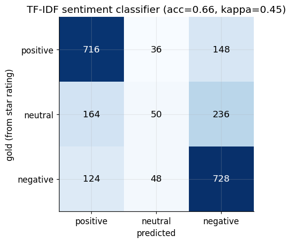

```python
# Figure: 3-class confusion matrix (the neutral class is the leaky one).
fig, ax = plt.subplots(figsize=(5.4, 4.6))
im = ax.imshow(cm, cmap='Blues')
ax.set_xticks(range(3)); ax.set_yticks(range(3))
ax.set_xticklabels(LAB); ax.set_yticklabels(LAB)
ax.set_xlabel('predicted'); ax.set_ylabel('gold (from star rating)')
for i in range(3):
    for j in range(3):
        ax.text(j, i, cm[i, j], ha='center', va='center',
                color='white' if cm[i, j] > cm.max() * 0.5 else 'black', fontsize=12)
ax.set_title(f'TF-IDF sentiment classifier (acc={acc3:.2f}, kappa={kap:.2f})')
plt.tight_layout(); plt.show()
```

### Embeddings as covariates + bootstrap CIs (ties to Chapters 3 & 4)

```python
# Regression: rating ~ 5 SVD components + review length, standardized coefficients.
pcs5 = S[:, :5]
Xr = StandardScaler().fit_transform(np.column_stack([pcs5, length]))
names = [f'PC{i+1}' for i in range(5)] + ['review_length']
rating = df['rating'].to_numpy().astype(float)
ols = LinearRegression().fit(Xr, rating)
print('Standardized OLS coefficients (rating ~ PC1..PC5 + review_length):')
for nm, c in zip(names, ols.coef_):
    print(f'  {nm:>13}: {c:+.3f}')
print(f'  {"intercept":>13}: {ols.intercept_:+.3f}')
print(f'  R^2 = {ols.score(Xr, rating):.3f}   (webbook ref, dense embeddings: ~0.46)')

# Bootstrap 95% CIs on every coefficient (Chapter 4 percentile method).
rng = np.random.default_rng(42)
n, B = len(rating), 1000
boot = np.zeros((B, Xr.shape[1]))
for b in range(B):
    idx = rng.choice(n, n, replace=True)
    boot[b] = LinearRegression().fit(Xr[idx], rating[idx]).coef_
print('\n95% bootstrap CIs (*** excludes 0):')
ci = {}
for i, nm in enumerate(names):
    lo, hi = np.percentile(boot[:, i], [2.5, 97.5])
    ci[nm] = (boot[:, i].mean(), lo, hi)
    star = '***' if (lo > 0 or hi < 0) else ''
    print(f'  {nm:>13}: {boot[:,i].mean():+.3f}  [{lo:+.3f}, {hi:+.3f}] {star}')
print(f"\n  review_length CI = [{ci['review_length'][1]:+.3f}, {ci['review_length'][2]:+.3f}] "
      "straddles 0 -> verbosity per se does NOT predict the rating.")
```

```
Standardized OLS coefficients (rating ~ PC1..PC5 + review_length):
            PC1: +0.168
            PC2: -0.004
            PC3: +0.356
            PC4: +0.218
            PC5: +0.173
  review_length: +0.014
      intercept: +3.000
  R^2 = 0.131   (webbook ref, dense embeddings: ~0.46)

95% bootstrap CIs (*** excludes 0):
            PC1: +0.168  [+0.137, +0.196] ***
            PC2: -0.004  [-0.031, +0.022]
            PC3: +0.357  [+0.329, +0.385] ***
            PC4: +0.219  [+0.192, +0.246] ***
            PC5: +0.173  [+0.148, +0.199] ***
  review_length: +0.014  [-0.016, +0.041]

  review_length CI = [-0.016, +0.041] straddles 0 -> verbosity per se does NOT predict the rating.
```

[figure not shown]

```python
# Figure: forest plot of the bootstrap coefficient CIs.
fig, ax = plt.subplots(figsize=(7.0, 3.8))
ys = np.arange(len(names))[::-1]
for yk, nm in zip(ys, names):
    mean, lo, hi = ci[nm]
    sig = (lo > 0 or hi < 0)
    col = GREEN if sig else RED
    ax.plot([lo, hi], [yk, yk], color=col, lw=3, solid_capstyle='round')
    ax.plot(mean, yk, 'o', color=col, ms=7)
ax.axvline(0, color='k', lw=1, ls='--')
ax.set_yticks(ys); ax.set_yticklabels(names)
ax.set_xlabel('standardized coefficient on rating')
ax.set_title('Bootstrap 95% CIs: review_length (red) includes 0; PCs (green) do not')
plt.tight_layout(); plt.show()
```

## Section 6.3 — Text Preprocessing for LLM Pipelines

Everything in an LLM pipeline is measured in **tokens**, not words: context windows, pricing, and embedding limits are all token budgets. We can't see GenAI Studio's tokenizer, so we *estimate* (1 word ≈ 1.3 tokens; 1 token ≈ 4 chars), manage a context budget, **chunk** long documents (fixed / overlap / semantic), and **clean noise while preserving signal** — note we do *not* lowercase or strip stop words, because LLMs understand grammar. All of this is pure-Python and fully reproducible.

```python
# Token estimation + context-window budget (deterministic heuristics).
def estimate_tokens(text, method='words'):
    if method == 'words':
        return int(len(text.split()) * 1.3)
    return len(text) // 4

sample = 'The bootstrap resamples data with replacement.'
print(f"sample: {sample!r}")
print(f"  word-based estimate: {estimate_tokens(sample, 'words')} tokens")
print(f"  char-based estimate: {estimate_tokens(sample, 'chars')} tokens")

def check_fits_context(text, model_context=8192, system_tokens=200, output_tokens=1000):
    est = estimate_tokens(text, 'words')
    available = model_context - system_tokens - output_tokens
    return est, available, est <= available

for name, text in [('a real review', df['text'].iloc[0]),
                   ('5000x a sentence', 'Statistical analysis reveals patterns. ' * 5000)]:
    est, avail, fits = check_fits_context(text)
    print(f"  {name:18s}: ~{est:>6,} input tokens vs {avail:,} available -> "
          f"{'fits' if fits else 'CHUNK required'}")
```

```
sample: 'The bootstrap resamples data with replacement.'
  word-based estimate: 7 tokens
  char-based estimate: 11 tokens
  a real review     : ~   109 input tokens vs 6,992 available -> fits
  5000x a sentence  : ~26,000 input tokens vs 6,992 available -> CHUNK required
```

```python
# Chunking strategies: fixed-size, overlap, and semantic (paragraph-aware).
def chunk_fixed(text, size=50):
    w = text.split()
    return [' '.join(w[i:i+size]) for i in range(0, len(w), size)]

def chunk_overlap(text, size=50, overlap=10):
    w, out, step = text.split(), [], size - overlap
    for i in range(0, len(w), step):
        c = ' '.join(w[i:i+size])
        if c:
            out.append(c)
        if i + size >= len(w):
            break
    return out

def chunk_semantic(text, max_size=40):
    paras = [p.strip() for p in text.split('\n\n') if p.strip()]
    out, cur, size = [], [], 0
    for p in paras:
        ps = len(p.split())
        if size + ps > max_size and cur:
            out.append('\n\n'.join(cur)); cur, size = [p], ps
        else:
            cur.append(p); size += ps
    if cur:
        out.append('\n\n'.join(cur))
    return out

long_text = ' '.join(f'Sentence {i} discusses topic {i % 5}.' for i in range(200))
fixed = chunk_fixed(long_text, 50)
over = chunk_overlap(long_text, 50, 10)
print(f'document: {len(long_text.split())} words')
print(f'  fixed (size 50)        : {len(fixed)} chunks')
print(f'  fixed + 10-word overlap: {len(over)} chunks  '
      f'(+{len(over)-len(fixed)} = {100*(len(over)/len(fixed)-1):.0f}% more, for boundary safety)')

structured = ('Intro\n\nThe bootstrap resamples with replacement to estimate a sampling '
              'distribution.\n\nMethod\n\nDraw n values with replacement, compute the statistic, '
              'repeat B times.\n\nIntervals\n\nThe percentile method uses bootstrap quantiles '
              'as the interval endpoints.')
sem = chunk_semantic(structured, max_size=20)
print(f'  semantic (<=20 words)  : {len(sem)} chunks, each a whole section:')
for i, c in enumerate(sem):
    print(f'    chunk {i} ({len(c.split())} w): {c[:48].replace(chr(10), " ")}...')
```

```
document: 1000 words
  fixed (size 50)        : 20 chunks
  fixed + 10-word overlap: 25 chunks  (+5 = 25% more, for boundary safety)
  semantic (<=20 words)  : 3 chunks, each a whole section:
    chunk 0 (12 w): Intro  The bootstrap resamples with replacement ...
    chunk 1 (12 w): Draw n values with replacement, compute the stat...
    chunk 2 (10 w): The percentile method uses bootstrap quantiles a...
```

```python
# Cleaning: remove NOISE (HTML, URLs, control chars, repeated whitespace),
# but KEEP signal (case, punctuation, stop words). Measure tokens saved on real reviews.
def clean_text(text):
    text = _re.sub(r'<[^>]+>', '', text)
    text = _re.sub(r'https?://\S+', '[URL]', text)
    text = _re.sub(r'\s+', ' ', text)
    text = _re.sub(r'[\x00-\x08\x0b\x0c\x0e-\x1f\x7f]', '', text)
    return text.strip()

raw_demo = ('<p>This is a <b>test</b> of the   cleaning pipeline.</p> '
            'Visit https://example.com/very/long/url for more info.')
print('raw  :', repr(raw_demo))
print('clean:', repr(clean_text(raw_demo)))

# On a real noisy slice of the corpus (use the ORIGINAL un-cleaned text from the bucket).
orig = [r['text'] for r in reviews][:300]   # 'reviews' holds the raw JSON
before = sum(estimate_tokens(t, 'words') for t in orig)
after = sum(estimate_tokens(clean_text(t), 'words') for t in orig)
print(f'\n300 raw reviews: ~{before:,} tokens -> ~{after:,} after cleaning '
      f'({100*(before-after)/before:.1f}% saved by stripping HTML/markup/whitespace)')
```

```
raw  : '<p>This is a <b>test</b> of the   cleaning pipeline.</p> Visit https://example.com/very/long/url for more info.'
clean: 'This is a test of the cleaning pipeline. Visit [URL] for more info.'

300 raw reviews: ~14,219 tokens -> ~14,136 after cleaning (0.6% saved by stripping HTML/markup/whitespace)
```

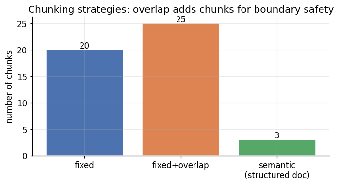

```python
# Figure: chunk count by strategy, and the overlap cost.
fig, ax = plt.subplots(figsize=(6.4, 3.6))
labels = ['fixed', 'fixed+overlap', 'semantic\n(structured doc)']
counts = [len(fixed), len(over), len(sem)]
bars = ax.bar(labels, counts, color=[BLUE, ORANGE, GREEN], edgecolor='white')
for b, c in zip(bars, counts):
    ax.text(b.get_x() + b.get_width()/2, c + 0.3, str(c), ha='center', fontsize=11)
ax.set_ylabel('number of chunks')
ax.set_title('Chunking strategies: overlap adds chunks for boundary safety')
plt.tight_layout(); plt.show()
```

**Read-out.** Token budgeting, chunking, and cleaning are the unglamorous glue of any LLM pipeline. Overlap trades ~25% more chunks for boundary coverage; semantic chunking keeps each section intact; and cleaning *noise* (not signal) trimmed real tokens for free. These chunks feed directly into retrieval (§6.5) and annotation (§6.4).

## Section 6.4 — LLM-Assisted Data Annotation

Labels are the expensive bottleneck of supervised learning. An LLM can annotate sentiment in minutes for pennies — but **is it reliable enough?** The honest tool is **Cohen's κ**, which corrects raw agreement for chance. The webbook ran `gemma3:12b` over 74 reviews against the gold label (derived from the star rating) and froze the **agreement matrix**; we reproduce its exact κ here from those counts — no API call needed — then bootstrap the κ (Chapter 4).

### The annotation call (read-only — needs an API key)

```
ai.select_model("gemma3:12b")
ANNOTATION_PROMPT = '''Classify the sentiment of the review.
Respond with ONLY: positive, negative, or neutral.
Review: {text}
Label:'''
def annotate(text):
    r = ai.chat(ANNOTATION_PROMPT.format(text=text)).strip().lower()
    return r if r in {"positive","negative","neutral"} else "unparseable"
# -> "Absolutely love this!" -> positive ;  "Broke in two days." -> negative
```

The annotations below are the webbook's **frozen `gemma3:12b` results** (the per-cell counts of the Figure 6.4.3 agreement matrix), so the κ reproduces exactly and offline.

```python
# Cohen's kappa from the frozen gemma3:12b vs. gold agreement matrix (74 reviews).
# Rows = gold (from star rating); columns = the LLM's predicted label.
gold = ['pos'] * 24 + ['neu'] * 23 + ['neg'] * 27
llm = (['pos'] * 18 + ['neu'] * 5  + ['neg'] * 1 +     # gold positive (24)
       ['pos'] * 2  + ['neu'] * 9  + ['neg'] * 12 +    # gold neutral  (23)
       ['pos'] * 1  + ['neu'] * 1  + ['neg'] * 25)     # gold negative (27)
LABELS = ['pos', 'neu', 'neg']
acc = accuracy_score(gold, llm)
kappa = cohen_kappa_score(gold, llm, labels=LABELS)
print(f'n = {len(gold)} reviews   accuracy = {acc:.3f}   Cohen kappa = {kappa:.3f}')
interp = ('almost perfect' if kappa > .8 else 'substantial' if kappa > .6
          else 'MODERATE' if kappa > .4 else 'fair/poor')
print(f'  interpretation: {interp} agreement')
print(f'  A 0.70 accuracy looks fine, but chance agreement among 3 classes is ~1/3;')
print(f'  removing it leaves only kappa = {kappa:.2f} -- the honest signal.')
agree_mat = confusion_matrix(gold, llm, labels=LABELS)
print('\nAgreement matrix (rows gold, cols LLM) order pos/neu/neg:')
print(agree_mat)
print(f"  diagonal (agreement) = {np.trace(agree_mat)} of {len(gold)}; biggest error = "
      f"gold-neutral labeled negative ({agree_mat[1,2]} of {agree_mat[1].sum()}).")
```

```
n = 74 reviews   accuracy = 0.703   Cohen kappa = 0.548
  interpretation: MODERATE agreement
  A 0.70 accuracy looks fine, but chance agreement among 3 classes is ~1/3;
  removing it leaves only kappa = 0.55 -- the honest signal.

Agreement matrix (rows gold, cols LLM) order pos/neu/neg:
[[18  5  1]
 [ 2  9 12]
 [ 1  1 25]]
  diagonal (agreement) = 52 of 74; biggest error = gold-neutral labeled negative (12 of 23).
```

```python
# Bootstrap the kappa (Chapter 4): how uncertain is 'moderate'?
rng = np.random.default_rng(42)
n = len(gold)
kappas = []
for _ in range(1000):
    idx = rng.choice(n, n, replace=True)
    try:
        kappas.append(cohen_kappa_score([gold[i] for i in idx],
                                        [llm[i] for i in idx], labels=LABELS))
    except ValueError:
        continue
kappas = np.array(kappas)
lo, hi = np.percentile(kappas, [2.5, 97.5])
print(f'bootstrap kappa: mean = {kappas.mean():.3f}   95% CI = [{lo:.3f}, {hi:.3f}]   '
      f'SE = {kappas.std():.3f}')
print(f'  The CI straddles the 0.6 "substantial" line -> we CANNOT claim substantial')
print('  agreement. Decision: route the ambiguous (3-star/neutral) reviews to humans')
print('  before trusting these labels at scale. Reporting the interval, not a bare')
print('  point estimate, is the statistical rigor (vs. blindly trusting the LLM).')
```

```
bootstrap kappa: mean = 0.544   95% CI = [0.386, 0.688]   SE = 0.078
  The CI straddles the 0.6 "substantial" line -> we CANNOT claim substantial
  agreement. Decision: route the ambiguous (3-star/neutral) reviews to humans
  before trusting these labels at scale. Reporting the interval, not a bare
  point estimate, is the statistical rigor (vs. blindly trusting the LLM).
```

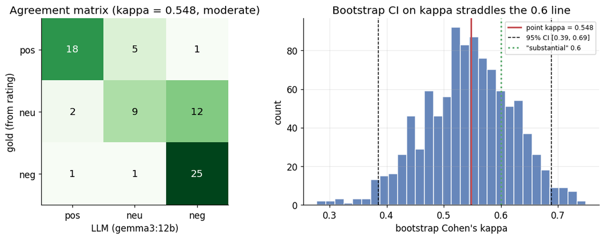

```python
# Figure: agreement matrix (left) + bootstrap kappa distribution (right).
fig, (a1, a2) = plt.subplots(1, 2, figsize=(11, 4.2))
im = a1.imshow(agree_mat, cmap='Greens')
a1.set_xticks(range(3)); a1.set_yticks(range(3))
a1.set_xticklabels(LABELS); a1.set_yticklabels(LABELS)
a1.set_xlabel('LLM (gemma3:12b)'); a1.set_ylabel('gold (from rating)')
for i in range(3):
    for j in range(3):
        a1.set_axisbelow(True)
        a1.text(j, i, agree_mat[i, j], ha='center', va='center',
                color='white' if agree_mat[i, j] > agree_mat.max()*0.5 else 'black', fontsize=12)
a1.grid(False)
a1.set_title(f'Agreement matrix (kappa = {kappa:.3f}, moderate)')
a2.hist(kappas, bins=30, color=BLUE, edgecolor='white', alpha=0.85)
a2.axvline(kappa, color=RED, lw=2, label=f'point kappa = {kappa:.3f}')
a2.axvline(lo, color='k', ls='--', lw=1); a2.axvline(hi, color='k', ls='--', lw=1,
                                                     label=f'95% CI [{lo:.2f}, {hi:.2f}]')
a2.axvline(0.6, color=GREEN, ls=':', lw=2, label='"substantial" 0.6')
a2.set_xlabel("bootstrap Cohen's kappa"); a2.set_ylabel('count')
a2.set_title('Bootstrap CI on kappa straddles the 0.6 line'); a2.legend(fontsize=8)
plt.tight_layout(); plt.show()
```

**Read-out.** κ = **0.548** — *moderate*, not substantial — and the bootstrap CI **[0.39, 0.69]** crosses the 0.6 threshold, so we honestly cannot claim better. The matrix points the finger at the neutral class (gold-neutral mislabeled negative 12/23), the same weak spot our TF-IDF classifier showed in §6.2. The decision this licenses is *hybrid*: LLM first pass, human review of the flagged neutral cases.

## Section 6.5 — Retrieval-Augmented Generation (RAG)

RAG fights hallucination by **retrieving** relevant source text and putting it in the prompt, so the model's job shifts from *recall* to *comprehension*. GenAI Studio offers a built-in knowledge-base API (read-only below); the instructive version is **manual RAG from scratch**: chunk → vectorize → retrieve top-k by cosine → build the augmented prompt. The retrieval half runs fully offline with TF-IDF; only the final generation needs the LLM.

### Built-in RAG (read-only — needs an API key)

```
file = ai.upload_file("stat418_syllabus.pdf")
kb = ai.create_knowledge_base("STAT 418 Materials")
ai.add_file_to_knowledge_base(kb.id, file.id)
ai.chat("What is the late homework policy?", collections=[kb.id])
# -> grounded answer quoting the syllabus, instead of "I don't have that info."
```

```python
# Manual RAG: a tiny statistics knowledge base, retrieved offline with TF-IDF.
documents = {
 'bootstrap.txt': ('The bootstrap is a resampling method introduced by Bradley Efron in '
   '1979. It estimates the sampling distribution of a statistic by repeatedly drawing '
   'samples with replacement from the observed data. Bootstrap confidence intervals use '
   'the percentile, basic, or BCa method. The bootstrap is distribution-free.'),
 'bayesian.txt': ('Bayesian inference treats parameters as random variables with prior '
   'distributions updated via Bayes theorem after observing data. Markov Chain Monte '
   'Carlo methods, especially Metropolis-Hastings and Hamiltonian Monte Carlo, sample '
   'from posterior distributions when analytical solutions are unavailable.'),
 'cross_validation.txt': ('Cross-validation estimates out-of-sample prediction error by '
   'partitioning data into folds. In k-fold cross-validation the model trains on k-1 '
   'folds and is evaluated on the held-out fold, rotating through all k. Leave-one-out '
   'is the special case k equals n.'),
}
def chunk_doc(text, size=40, overlap=8):
    w, out, step = text.split(), [], size - overlap
    for i in range(0, len(w), step):
        c = ' '.join(w[i:i+size])
        if c.strip():
            out.append(c)
        if i + size >= len(w):
            break
    return out

rag_chunks, rag_src = [], []
for fn, content in documents.items():
    for c in chunk_doc(content):
        rag_chunks.append(c); rag_src.append(fn)
rag_vec = TfidfVectorizer(stop_words='english')
rag_M = rag_vec.fit_transform(rag_chunks)
print(f'indexed {len(rag_chunks)} chunks from {len(documents)} documents')

def retrieve(query, k=3):
    sims = cosine_similarity(rag_vec.transform([query]), rag_M).ravel()
    top = np.argsort(sims)[::-1][:k]
    return [(rag_src[i], sims[i], rag_chunks[i]) for i in top]

query = 'How do I construct a confidence interval without assumptions?'
hits = retrieve(query)
print(f"\nquery: {query!r}\nretrieved top-3:")
for s, sim, c in hits:
    print(f"  [{sim:.3f}] [{s}] {c[:60]}...")

# The augmented prompt we would send (the generation step needs the LLM; shown, not run).
context = '\n\n'.join(f'[{s}] {c}' for s, _, c in hits)
print('\n--- augmented prompt (sent to ai.chat in production) ---')
print(f'Answer ONLY from the context.\n### Context ###\n{context[:160]}...\n'
      f'Question: {query}\nAnswer:')
```

```
indexed 4 chunks from 3 documents

query: 'How do I construct a confidence interval without assumptions?'
retrieved top-3:
  [0.210] [bootstrap.txt] The bootstrap is a resampling method introduced by Bradley E...
  [0.000] [cross_validation.txt] Cross-validation estimates out-of-sample prediction error by...
  [0.000] [bayesian.txt] Bayesian inference treats parameters as random variables wit...

--- augmented prompt (sent to ai.chat in production) ---
Answer ONLY from the context.
### Context ###
[bootstrap.txt] The bootstrap is a resampling method introduced by Bradley Efron in 1979. It estimates the sampling distribution of a statistic by repeatedly dr...
Question: How do I construct a confidence interval without assumptions?
Answer:
```

```python
# Evaluate retrieval (offline): Precision@k and hit@k over labelled queries.
queries = ['How does bootstrap resampling work?',
           'What is a prior distribution?',
           'How many folds in cross-validation?']
expected = ['bootstrap.txt', 'bayesian.txt', 'cross_validation.txt']
precs, hits_at_k = [], []
for q, exp in zip(queries, expected):
    got = [s for s, _, _ in retrieve(q, k=3)]
    precs.append(sum(s == exp for s in got) / 3)     # fraction of top-3 from right source
    hits_at_k.append(1.0 if exp in got else 0.0)     # did we retrieve the right source at all
    print(f"  q={q[:34]:34s} top-3 sources={got}")
print(f'\nPrecision@3 = {np.mean(precs):.3f}   hit@3 = {np.mean(hits_at_k):.3f}')
print('  hit@3 = 1.00: the correct source is always retrieved. Precision@3 < 1 because')
print('  TF-IDF keyword overlap mis-ranks some chunks (e.g. "distribution" pulls')
print('  bootstrap for a Bayesian query) -- the precise gap dense embeddings close.')
```

```
  q=How does bootstrap resampling work top-3 sources=['bootstrap.txt', 'bootstrap.txt', 'cross_validation.txt']
  q=What is a prior distribution?      top-3 sources=['bootstrap.txt', 'bayesian.txt', 'bootstrap.txt']
  q=How many folds in cross-validation top-3 sources=['cross_validation.txt', 'bayesian.txt', 'bootstrap.txt']

Precision@3 = 0.444   hit@3 = 1.000
  hit@3 = 1.00: the correct source is always retrieved. Precision@3 < 1 because
  TF-IDF keyword overlap mis-ranks some chunks (e.g. "distribution" pulls
  bootstrap for a Bayesian query) -- the precise gap dense embeddings close.
```

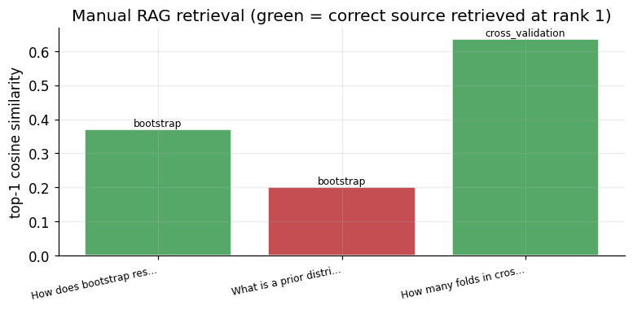

```python
# Figure: top-1 retrieval similarity per query, coloured by whether the source is right.
fig, ax = plt.subplots(figsize=(7.2, 3.6))
top1 = [retrieve(q, k=1)[0] for q in queries]
sims = [t[1] for t in top1]
right = [t[0] == e for t, e in zip(top1, expected)]
cols = [GREEN if r else RED for r in right]
bars = ax.bar(range(len(queries)), sims, color=cols, edgecolor='white')
ax.set_xticks(range(len(queries)))
ax.set_xticklabels([q[:22] + '...' for q in queries], rotation=12, ha='right', fontsize=8)
for b, t in zip(bars, top1):
    ax.text(b.get_x() + b.get_width()/2, t[1] + 0.01, t[0].replace('.txt', ''),
            ha='center', fontsize=8)
ax.set_ylabel('top-1 cosine similarity')
ax.set_title('Manual RAG retrieval (green = correct source retrieved at rank 1)')
plt.tight_layout(); plt.show()
```

**Read-out.** A retriever is just nearest-neighbour search (§6.2) over document chunks (§6.3): index once, embed the query, take the top-k, paste them into the prompt. Offline TF-IDF already gets **hit@3 = 1.0** (the right source is always present) at **Precision@3 ≈ 0.44**; the rank-1 misses are exactly where dense embeddings help. Retrieval is measurable (Precision@k / Recall@k) and is *one specific tool* — the general pattern is §6.7.

## Section 6.6 — Prompt Engineering for Data Science

A prompt is the *program*: version it, parameterize it, test it. The webbook builds a toolkit — clear instructions, delimiters, strict-JSON output, few-shot examples, chain-of-thought, and **self-consistency**. Self-consistency is the one with a direct statistical analogue: run the same prompt several times and take the **majority vote**, exactly as the bootstrap resamples to quantify uncertainty. We make that concrete with an offline Monte-Carlo simulation (a Condorcet-jury calculation), no LLM required.

### Prompts as code & self-consistency (read-only — needs an API key)

```
SENTIMENT = ("Classify as positive, negative, or neutral. One word only.\n"
             "Text: {text}\nLabel:")               # versioned template, stored in repo
# self-consistency: majority vote over independent runs (Wang et al., 2022)
runs = [ai.chat(SENTIMENT.format(text=t)).strip().lower() for _ in range(7)]
majority, k = Counter(runs).most_common(1)[0]
confidence = k / len(runs)        # agreement rate == a natural uncertainty measure
```

```python
# Self-consistency as a bootstrap: does majority-vote over noisy reasoning paths help?
# Simulate a 'reasoner' that is correct with probability p on each independent run;
# take the majority vote over k runs and measure accuracy (a Condorcet-jury result).
def majority_vote_accuracy(p, k, trials=20000, seed=418):
    rng = np.random.default_rng(seed)
    draws = rng.random((trials, k)) < p          # each run correct w.p. p
    return (draws.sum(axis=1) > k / 2).mean()    # majority correct

print('Per-path accuracy p = 0.65 (a shaky single answer):')
for k in [1, 3, 5, 7, 9, 15]:
    print(f'  majority vote of k={k:2d} runs -> accuracy {majority_vote_accuracy(0.65, k):.3f}')
print('\nBelow the p=0.5 break-even, voting HURTS (it amplifies a biased reasoner):')
for k in [1, 5, 15]:
    print(f'  p=0.45, k={k:2d} -> {majority_vote_accuracy(0.45, k):.3f}')
print('\nHigh agreement across runs is like a narrow bootstrap CI: the answer is robust.')
print('Low agreement is a wide CI: the model is uncertain and the answer is suspect.')
```

```
Per-path accuracy p = 0.65 (a shaky single answer):
  majority vote of k= 1 runs -> accuracy 0.654
  majority vote of k= 3 runs -> accuracy 0.717
  majority vote of k= 5 runs -> accuracy 0.764
  majority vote of k= 7 runs -> accuracy 0.797
  majority vote of k= 9 runs -> accuracy 0.827
  majority vote of k=15 runs -> accuracy 0.890

Below the p=0.5 break-even, voting HURTS (it amplifies a biased reasoner):
  p=0.45, k= 1 -> 0.451
  p=0.45, k= 5 -> 0.408
  p=0.45, k=15 -> 0.350

High agreement across runs is like a narrow bootstrap CI: the answer is robust.
Low agreement is a wide CI: the model is uncertain and the answer is suspect.
```

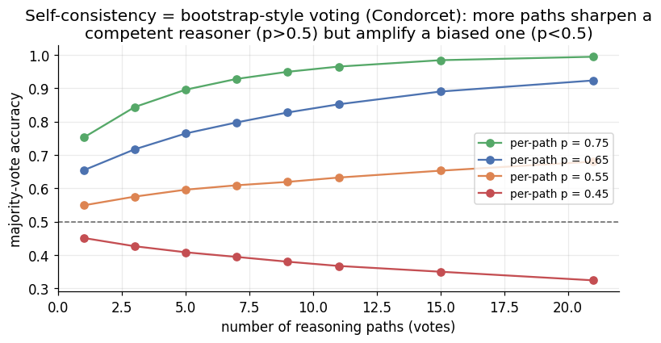

```python
# Figure: majority-vote accuracy vs number of reasoning paths, for several p.
fig, ax = plt.subplots(figsize=(7.2, 4.0))
ks = np.array([1, 3, 5, 7, 9, 11, 15, 21])
for p, col in [(0.75, GREEN), (0.65, BLUE), (0.55, ORANGE), (0.45, RED)]:
    accs = [majority_vote_accuracy(p, int(k)) for k in ks]
    ax.plot(ks, accs, 'o-', color=col, label=f'per-path p = {p}')
ax.axhline(0.5, color='k', lw=1, ls='--', alpha=0.6)
ax.set_xlabel('number of reasoning paths (votes)'); ax.set_ylabel('majority-vote accuracy')
ax.set_title('Self-consistency = bootstrap-style voting (Condorcet): more paths sharpen a\n'
             'competent reasoner (p>0.5) but amplify a biased one (p<0.5)')
ax.legend(fontsize=9); plt.tight_layout(); plt.show()
```

**Read-out.** Self-consistency is a Condorcet jury: if each run is better than a coin flip ($p>0.5$), majority vote over more runs drives accuracy up; if it is biased ($p<0.5$), voting only entrenches the error. The agreement rate is a free, interpretable uncertainty measure — the same logic as a bootstrap CI, and the basis for the uncertainty quantification in §6.8.

## Section 6.7 — Tool Use

LLMs are weak at exact arithmetic, live data, and reaching private systems. **Tool use** (function calling) closes the gap: you describe functions; the model *requests* a call with arguments; **your code** runs it and returns the result; the model answers grounded in that result. The cycle is **request → execute → return → answer** — control never leaves your program. In the GenAI Studio SDK, the `@tool` decorator turns a typed function's **hints + docstring** into the JSON schema the model reads. We can't call the SDK offline, but we can reproduce that schema generation with pure-Python introspection to show *the docstring is the interface*.

### The `@tool` cycle (read-only — needs an API key)

```
from genai_studio.agents import tool
@tool
def query_dataset(table: str, column: str, condition: str = "") -> str:
    "Return values from a named dataset, optionally filtered."
    ...
resp = ai.chat_raw(messages, tools=[query_dataset.spec.to_openai()], tool_choice="auto")
call = resp.choices[0].message.tool_calls[0]          # model REQUESTS the call
result = query_dataset(**json.loads(call.function.arguments))   # YOUR code runs it
# ...append the result as a 'tool' message, ask the model to finish -> grounded answer
```

```python
# Offline: derive the JSON schema a model would see, straight from type hints + docstring.
import inspect, typing

def build_tool_schema(fn):
    hints = typing.get_type_hints(fn)
    sig = inspect.signature(fn)
    py2json = {str: 'string', int: 'integer', float: 'number', bool: 'boolean'}
    props, required = {}, []
    doc_lines = [ln.strip() for ln in (fn.__doc__ or '').splitlines()]
    arg_docs = {}
    for ln in doc_lines:
        if ':' in ln and not ln.lower().startswith(('args', 'returns')):
            k, _, v = ln.partition(':')
            arg_docs[k.strip()] = v.strip()
    for name, param in sig.parameters.items():
        props[name] = {'type': py2json.get(hints.get(name, str), 'string'),
                       'description': arg_docs.get(name, '')}
        if param.default is inspect._empty:
            required.append(name)
        else:
            props[name]['default'] = param.default
    return {'name': fn.__name__, 'parameters': {'type': 'object',
            'properties': props, 'required': required}}

def z_score(value: float, mean: float, sd: float, two_sided: bool = True) -> str:
    ("Standardize a value against a distribution.\n"
     "value: the observed value to standardize.\n"
     "mean: the distribution mean.\n"
     "sd: the distribution standard deviation (must be > 0).\n"
     "two_sided: whether to report a two-sided tail.")
    return str((value - mean) / sd)

print(json.dumps(build_tool_schema(z_score), indent=2))
print(f"\nrequired args (no default): {build_tool_schema(z_score)['parameters']['required']}")
print('A decorated tool is still an ordinary function:')
print('  z_score(value=130, mean=100, sd=15) =', z_score(130, 100, 15), '(a clean 2.0)')
print('\nThe model never runs this -- it only emits {name, arguments}; your code executes.')
```

```
{
  "name": "z_score",
  "parameters": {
    "type": "object",
    "properties": {
      "value": {
        "type": "number",
        "description": "the observed value to standardize."
      },
      "mean": {
        "type": "number",
        "description": "the distribution mean."
      },
      "sd": {
        "type": "number",
        "description": "the distribution standard deviation (must be > 0)."
      },
      "two_sided": {
        "type": "boolean",
        "description": "whether to report a two-sided tail.",
        "default": true
      }
    },
    "required": [
      "value",
      "mean",
      "sd"
    ]
  }
}

required args (no default): ['value', 'mean', 'sd']
A decorated tool is still an ordinary function:
  z_score(value=130, mean=100, sd=15) = 2.0 (a clean 2.0)

The model never runs this -- it only emits {name, arguments}; your code executes.
```

**Read-out.** The model's type hints and docstring *are* the tool interface — a vague docstring yields vague calls. Tool use turns the model's job on a hard sub-task from *estimation* (a noisy guess) into *routing* (pick the tool + arguments) and delegates the exact work to deterministic code. Chaining many such calls in an autonomous loop is an **agent** — powerful, but reliability falls off with each step, so STAT 418 stops at single tool use.

## Section 6.8 — Reliability and Evaluation

LLM outputs cannot be trusted by default: **hallucination**, **inconsistency**, and **miscalibration**. Here we measure the last two offline. **Calibration**: a model is well-calibrated if, among predictions it makes with 80% confidence, ~80% are right; a **reliability diagram** and the **Expected Calibration Error (ECE)** quantify the gap. Then we run a full **evaluation protocol** — accuracy, F1, κ — against deployment thresholds, reusing our §6.2 classifier as the system under test.

```python
# Reliability diagram + ECE on a deliberately miscalibrated set (reproduces book 0.149).
def reliability_diagram(conf, correct, n_bins=10):
    bins = np.linspace(0, 1, n_bins + 1)
    bc, ba, bn = [], [], []
    for i in range(n_bins):
        m = (conf >= bins[i]) & (conf < bins[i + 1])
        if m.sum() > 0:
            bc.append(conf[m].mean()); ba.append(correct[m].mean()); bn.append(m.sum())
    ece = sum(c * abs(a - m) for c, a, m in zip(bn, ba, bc)) / sum(bn)
    return np.array(bc), np.array(ba), np.array(bn), ece

np.random.seed(42)
conf = np.random.beta(5, 2, 50)            # stated confidences
true_p = conf * 0.85 + 0.05               # actual accuracy is LOWER than stated
correct = np.random.binomial(1, true_p)
bc, ba, bn, ece = reliability_diagram(conf, correct)
print(f'Expected Calibration Error (ECE) = {ece:.3f}   (> 0.1 -> notably miscalibrated)')
for c, a, k in zip(bc, ba, bn):
    print(f'  stated conf {c:.2f}: actual accuracy {a:.2f} (n={k:2d}) '
          f"[{'overconfident' if c > a else 'underconfident'}]")
```

```
Expected Calibration Error (ECE) = 0.149   (> 0.1 -> notably miscalibrated)
  stated conf 0.39: actual accuracy 0.50 (n= 2) [underconfident]
  stated conf 0.50: actual accuracy 0.67 (n= 3) [underconfident]
  stated conf 0.55: actual accuracy 0.57 (n= 7) [underconfident]
  stated conf 0.65: actual accuracy 0.30 (n=10) [overconfident]
  stated conf 0.75: actual accuracy 0.67 (n=18) [overconfident]
  stated conf 0.84: actual accuracy 1.00 (n= 6) [underconfident]
  stated conf 0.94: actual accuracy 0.75 (n= 4) [overconfident]
```

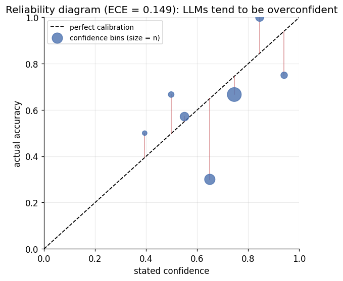

```python
# Figure: the reliability diagram (points below the diagonal = overconfident).
fig, ax = plt.subplots(figsize=(5.6, 5.2))
ax.plot([0, 1], [0, 1], 'k--', lw=1.2, label='perfect calibration')
ax.scatter(bc, ba, s=np.array(bn) * 18, color=BLUE, alpha=0.8, zorder=3,
           label='confidence bins (size = n)')
for c, a in zip(bc, ba):
    ax.plot([c, c], [c, a], color=RED, lw=1, alpha=0.6)
ax.set_xlim(0, 1); ax.set_ylim(0, 1)
ax.set_xlabel('stated confidence'); ax.set_ylabel('actual accuracy')
ax.set_title(f'Reliability diagram (ECE = {ece:.3f}): LLMs tend to be overconfident')
ax.legend(loc='upper left', fontsize=9); plt.tight_layout(); plt.show()
```

```python
# Evaluation protocol: score our Section 6.2 TF-IDF classifier against deployment gates.
metrics = {'accuracy': acc3, 'f1_weighted': f1w, 'kappa': kap}
DEPLOY = {'accuracy': 0.80, 'f1_weighted': 0.75, 'kappa': 0.60}     # minimums
print('Deployment readiness (3-class sentiment system):')
for m, thresh in DEPLOY.items():
    val = metrics[m]
    print(f'  {m:12s} = {val:.3f}  (need >= {thresh:.2f})  '
          f"{'PASS' if val >= thresh else 'FAIL'}")
# Binary system for contrast.
print(f'\n  binary pos/neg CV accuracy = {cv_acc.mean():.3f}  (>= 0.80) '
      f"{'PASS' if cv_acc.mean() >= 0.80 else 'FAIL'}")
print('Verdict: the binary system clears the bar; the 3-class system FAILS on the')
print('neutral class -- deploy binary auto-labelling, route neutrals to human review.')
```

```
Deployment readiness (3-class sentiment system):
  accuracy     = 0.664  (need >= 0.80)  FAIL
  f1_weighted  = 0.625  (need >= 0.75)  FAIL
  kappa        = 0.451  (need >= 0.60)  FAIL

  binary pos/neg CV accuracy = 0.824  (>= 0.80) PASS
Verdict: the binary system clears the bar; the 3-class system FAILS on the
neutral class -- deploy binary auto-labelling, route neutrals to human review.
```